# Classical Linear Regression using Python with Scikit-Learn

Hey there! As an R user, I'm excited to be diving into the world of Python and what better way to start than with a classic linear regression example. This is my 1st notebook using JupyterLab and Python. In this notebook, I'll be showcasing my newlearnt Python skills by analyzing the BMD_baseline dataset which has both numeric and catgorical variables.

This dataset is information about 566 women who participated in a clinical trial of hormone replacement therapy. The goal is to uncover the relationship between their bone mineral density (BMD), age, and body mass index (BMI) - all factors that play a role in affecting BMD.

So, if you're afellow R user like me, or just curious about classical linear regression in general, join me on this journey as we uncover insights and have a little fun along the way!

## Why learning linear regression ?

Linear regression is the most simple ‘Machine Learning’ and important algorithms.

- serves as the foundation for more advanced statistical techniques
- widely used in various fields like economics, finance, biology, and engineering, to mention a few
- easy to use

In this notebook, I will talk about

1. Importing libraries and the data
2. Data exploratation
3. Modelling
4. Model fit and diagnostic checking

## Importing libraries and the data

```python
# import libraries
import pandas as pd
import numpy as np
import seaborn as sns
from sklearn.linear_model import LinearRegression
import matplotlib.pyplot as plt
from scipy import stats
import warnings # keep Notebook clean
warnings.filterwarnings('ignore')
```

```python
# read data
bmd_data = pd.read_csv('bmd.baseline.csv')
bmd_data.head() # first 5 cases
```

|  | SUBJ | MONTH | GROUP | BMD | SMOKING | HRT | BMI | YRS | AGE | bmi.cat |
| --- | --- | --- | --- | --- | --- | --- | --- | --- | --- | --- |
| 0 | 1 | 99 | 2 | 0.78 | 3 | NO | 26.850816 | 1.750000 | 53 | 3 |
| 1 | 2 | 99 | 2 | 0.90 | 1 | NO | 24.221453 | 1.166667 | 54 | 2 |
| 2 | 3 | 99 | 1 | 0.80 | 1 | NO | 19.631172 | 2.750000 | 58 | 2 |
| 3 | 4 | 99 | 3 | 0.79 | 2 | NO | 22.621843 | 2.916667 | 49 | 2 |
| 4 | 5 | 99 | 1 | 1.02 | 1 | NO | 21.049818 | 1.250000 | 46 | 2 |

Oops, it would be better ifcolumn names are lower-case.

```python
bmd_data.columns = bmd_data.columns.str.lower()
bmd_data.head()
```

|  | subj | month | group | bmd | smoking | hrt | bmi | yrs | age | bmi.cat |
| --- | --- | --- | --- | --- | --- | --- | --- | --- | --- | --- |
| 0 | 1 | 99 | 2 | 0.78 | 3 | NO | 26.850816 | 1.750000 | 53 | 3 |
| 1 | 2 | 99 | 2 | 0.90 | 1 | NO | 24.221453 | 1.166667 | 54 | 2 |
| 2 | 3 | 99 | 1 | 0.80 | 1 | NO | 19.631172 | 2.750000 | 58 | 2 |
| 3 | 4 | 99 | 3 | 0.79 | 2 | NO | 22.621843 | 2.916667 | 49 | 2 |
| 4 | 5 | 99 | 1 | 1.02 | 1 | NO | 21.049818 | 1.250000 | 46 | 2 |

The bmi_cat column in the data represents a categorical variable that indicates the body mass index (BMI) category of an individual. The categories are defined as follows:

- 1: underweight (BMI < 18.5)
- 2: normal (BMI between 18.5 and 24.9)
- 3: overweight (BMI between 25 and 29.9)
- 4: obese (BMI ≥ 30)

As mentioned above, the goal is to uncover the relationship between their bone mineral density (BMD), age, and body mass index (BMI) - all factors that play a role in affecting BMD. The reponse variable (also known as the dependent variable) in this case is BMD and the predictor variables (also known as independent variables or features) are age and BMI.

## Data Exploration

Before embarking on modelling, we always examine data graphically and numerically. We firstly look at the frequency table of BMI category:

```python
bmi_cat_frequency = bmd_data['bmi.cat'].value_counts()
bmi_cat_frequency
```

```
2    294
3    190
4     81
1      1
Name: bmi.cat, dtype: int64
```

We can see the underweight category (bmi.cat = 1) is not viable with only one observation. It would be better to combine it with the normal category (bmi.cat = 2) for analysis.

```python
bmd_data['bmi_cat2'] = np.where(bmd_data['bmi.cat'] == 1, 2, bmd_data['bmi.cat'])
# This code creates a new column called bmi_cat2 and checks the values of bmi_cat column.
# If the value is 1, it replaces it with 2, otherwise, it keeps the original value in the bmi_cat column.
bmd_data['bmi_cat2'].value_counts()
```

```
2    295
3    190
4     81
Name: bmi_cat2, dtype: int64
```

Because bmi_cat2 is categorical and BMD is continuous, we construct boxplots of BMD against bmi_cat2, and a scatterplot of BMD against age.

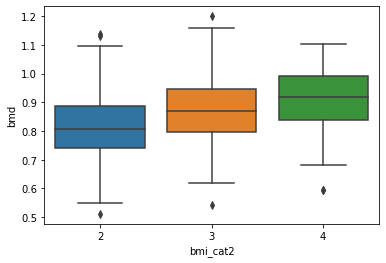

```python
# visualize the relationship between the predictors and the response using booxplot and scatterplot

sns.boxplot(x='bmi_cat2', y='bmd', data=bmd_data)
```

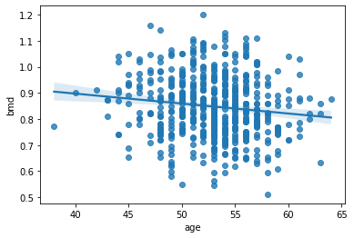

```python
sns.regplot(x='age', y='bmd', data=bmd_data)
```

We see a trend of increasing BMD with increasing BMI category, i.e. women with higher BMI tend to have higher BMD. The BMD-age relationship is much weaker, but there is a small negative trend (i.e. BMD decreases with increasing age).

## Modelling

We specify the model: $$Y_i = \beta_0 + \beta_2z_{i3} + \beta_3z_{i4} + \beta_{age}x_i +\epsilon_i$$

Where

$Y_i$= BMD of $i$th subject, in $g/cm^2$

$ z_{i3} = \left\{ \begin{array}\\ 1 & \mbox{if } \ bmi.cat2 = 3 \\ 0 & \mbox{else.} \end{array} \right. $

$ z_{i4} = \left\{ \begin{array}\\ 1 & \mbox{if } \ bmi.cat2 = 4 \\ 0 & \mbox{else.} \end{array} \right. $

$x_i$ = age of $i$th subject

```python
# Extract the predictors and response variables
X = bmd_data[['bmi_cat2', 'age']]

# bmi_cat2 is categorical variable, so we add dummy variables
X = pd.get_dummies(data=X, columns=['bmi_cat2'], drop_first=True)
X.head()
```

|  | age | bmi_cat2_3 | bmi_cat2_4 |
| --- | --- | --- | --- |
| 0 | 53 | 1 | 0 |
| 1 | 54 | 0 | 0 |
| 2 | 58 | 0 | 0 |
| 3 | 49 | 0 | 0 |
| 4 | 46 | 0 | 0 |

```python
y = bmd_data['bmd']

# Fit the linear regression model
lm = LinearRegression().fit(X, y)

# Print the coefficients
coeff_parameter = pd.DataFrame(lm.coef_,X.columns,columns=['Coefficient'])
coeff_parameter
```

|  | Coefficient |
| --- | --- |
| age | -0.005005 |
| bmi_cat2_3 | 0.062756 |
| bmi_cat2_4 | 0.101288 |

### Model interpretation

$$Y_i = \beta_0 + \beta_2z_{i3} + \beta_3z_{i4} + \beta_{age}x_i +\epsilon_i$$

$$BMD = 1.077 + 0.062756 * z_{i3} + 0.101288 * z_{i4} -0.005005 * age$$

This means that:

- The effect of an increase in age of one year is a decrease in expected BMD of 0.005 g/cm2.
- The effect of being overweight, compared with normal weight, is an increase in expected BMD of 0.063 g/cm2.
- The e ect of being obese, compared with normal weight, is an increase in expected BMD of 0.101 g/cm2.

### Using model for predictation

Let's say that there was a new observation where the age was 50 and bmi_cat was 3, what would we predict for the BMD in this case?

```python
X_new = pd.DataFrame({'age': [50], 'bmi_cat2_3': 1, 'bmi_cat2_4': 0})
# use the model to make predictions on a new value
lm.predict(X_new)
```

```
array([0.88966767])
```

## Model fit and diagnostic checking

### Model fit

The most common way to evaluate the overall fit of a linear model is by the R-squared value. R-squared is the proportion of variance explained, meaning the proportion of variance in the observed data that is explained by the model, or the reduction in error over the null model. (The null model just predicts the mean of the observed response, and thus it has an intercept and no slope). R-squared is between 0 and 1, and higher is better.

```python
# calculate the R-squared
lm.score(X, y)
```

```
0.12508730481588126
```

We see from the output that $R^2$ = 0.125. This means that the model explains 12.5% of the variation in BMD. While this does not sound particularly high, in medical studies one often gets low R2. Bone mineral density is a complicated phys- iological phenomenon, and it is not surprising that BMI and age only explain a fairly small proportion of the observed variation.

### Diagnostic plots produced by the model

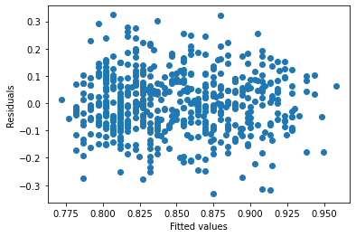

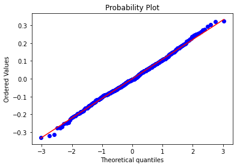

```python
# calculate residuals
y_pred = lm.predict(X)
residuals = y - y_pred

# plot residuals vs fitted
plt.scatter(y_pred, residuals)
plt.xlabel('Fitted values')
plt.ylabel('Residuals')
plt.show()

# plot normal Q-Q plot
stats.probplot(residuals, dist="norm", plot=plt)
plt.show()
```

The scatterplot of residuals against $\hat{y_i}$ appears random, indicating conformity with the assumption of equal variance. The normal scores plot (bellow) indicates that the $\epsilon_i$ are normally distributed.